# Inferential Statistics - Introduction

### *Moving on to the next phase of Data Analysis*

Prepared by Shakhizat Matayev

## Table of Content

1. About the dataset
2. EDA
3. Individual Tasks

## 1. About the Dataset

Kolesa.kz - this is not just an online free classifieds board, but a real marketplace and electronic directory for motorists. The website has advertisements from individuals and companies and hold the most voluminous block of information for those who want to buy / sell any type of vehicles (cars, including new cars, motorcycles, boats and boats), spare parts, special equipment, as well as find / offer automobile services.

The dataset is parsed data from the website which contains all of the ads of light vehicles for Almaty region in June month of 2020. It containt over 19k ads across 10 variables such as car brand, price, year of manufacturing, engine size, color, wheel placement, transmission, type of base, and the link to original ad (might not be actual).

## 2. Data Cleaning and Basic EDA

Examples of basic EDA to get you started

## 3. Practice Tasks

Perform following analysis

1. Clean the data if necessary
2. Apply univariate analysis technique: at least 1 on numeric variable and minimum 1 on categorical variable.
3. Pick any two variables and attempt to show an (interesting) relation via visualization. Explain your plot.
4. Formualate a hopythesis about this dataset and test your hypothesis.
5. In your opinion, which of the variables help to predict the price. Why?

```python
#import the useful libraries.
import numpy as np
import pandas as pd
import seaborn as sns
import scipy.stats as stats
import matplotlib.pyplot as plt
%matplotlib inline

filepath = "Almaty_after_COVID-19_clean.csv"

# Read the data set of "Marketing Analysis" in data.
data= pd.read_csv(filepath, sep=";")

# Printing the data
data.head(10)
```

|  | car | price | city | year | base | engine | color | wheel | url | transmission |
| --- | --- | --- | --- | --- | --- | --- | --- | --- | --- | --- |
| 0 | Volkswagen Multivan | 9300000 | Алматы | 2008 | минивэн | 3.2 | черный | левый руль | https://kolesa.kz//a/show/105581877 | КПП автомат |
| 1 | Lexus LX 470 | 4900000 | Алматы | 1998 | внедорожник | 4.7 | белый | левый руль | https://kolesa.kz//a/show/105168303 | КПП автомат |
| 2 | Hyundai Trajet | 3100000 | Алматы | 2000 | минивэн | 2.7 | голубой | левый руль | https://kolesa.kz//a/show/103502834 | КПП автомат |
| 3 | Mercedes-Benz E 230 | 2300000 | Алматы | 1996 | седан | 2.3 | черный | левый руль | https://kolesa.kz//a/show/105648584 | КПП механика |
| 4 | Audi Q8 | 45000000 | Алматы | 2020 | кроссовер | 3.0 | синий | левый руль | https://kolesa.kz//a/show/105544860 | КПП автомат |
| 5 | Volkswagen Golf | 1300000 | Алматы | 1992 | хэтчбек | 1.8 | синий | левый руль | https://kolesa.kz//a/show/105438362 | КПП механика |
| 6 | Volkswagen Polo | 4375000 | Алматы | 2015 | седан | 1.6 | белый | левый руль | https://kolesa.kz//a/show/105393585 | КПП автомат |
| 7 | Chevrolet Cruze | 3300000 | Алматы | 2012 | седан | 1.8 | серебристый | левый руль | https://kolesa.kz//a/show/98713714 | КПП автомат |
| 8 | Nissan Terrano | 5000000 | Алматы | 2014 | кроссовер | 2.0 | синий | левый руль | https://kolesa.kz//a/show/105548376 | КПП автомат |
| 9 | Audi A8 | 1350000 | Алматы | 1997 | седан | 3.7 | серебристый | левый руль | https://kolesa.kz//a/show/105581778 | КПП автомат |

```python
# Check the size of the dataset
data.shape
```

```
(19190, 10)
```

```python
# Checking the missing values
data.isnull().sum()
```

```
car              0
price            0
city             0
year             0
base             0
engine          12
color            0
wheel            0
url              8
transmission     0
dtype: int64
```

```python
# Dropping the records with engine size data missing in data dataframe.
data = data[~data.engine.isnull()].copy()
```

```python
# Drop the url as it is of no use.
data.drop('url', axis = 1, inplace = True)
```

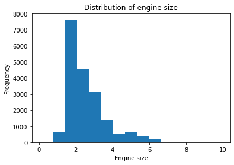

```python
# apply some visualizations
plt.hist(data.engine, bins=15)
plt.gca().set(title='Distribution of engine size', xlabel='Engine size', ylabel='Frequency');
```

### Looking at `price` column

Using the `describe()` funtion we looked at `price` column separately. This is type of Univariate analysis to look for central tendency (mean, median, quartiles) and dispersion (min-max, standard deviation). The prices are in Tenge currency, some of them are very large (expensive) numbers. Therefore, for easy reading, I applied some number formatting using `option_context()` of python's `pandas` library.

```python
#let's look at price column
with pd.option_context('float_format', '{:,.2f}'.format):
    print(data.price.describe())
```

```
count        19,178.00
mean      5,837,206.64
std       7,805,823.17
min          10,000.00
25%       1,800,000.00
50%       3,600,000.00
75%       6,647,805.50
max     133,577,000.00
Name: price, dtype: float64
```

There are a lot of information you can get from these numbers. For example, `mean` is mich higher than `median` (50%). This indicates that there are some outliers, i.e. cars with very high prices. You can see that by looking at the `max` value.

Wow! The maximum price for a car in our dataset is `133,577,000.00` tenge. I wonder what kind of car it is. Let's find out. For that we can use so called *slicing* feature of `pandas` library.

```python
#display cars with prices above 100,000,000
#in python you can use underscore _ as number separator for easier reading
data[data['price'] >= 100_000_000].sort_values('price', ascending=False)
```

|  | car | price | city | year | base | engine | color | wheel | transmission |
| --- | --- | --- | --- | --- | --- | --- | --- | --- | --- |
| 4314 | Mercedes-Benz G 63 AMG | 133577000 | Алматы | 2020 | внедорожник | 4.0 | черный | левый руль | КПП автомат |
| 13076 | Mercedes-Benz G 63 AMG | 133000000 | Алматы | 2019 | внедорожник | 4.0 | черный | левый руль | КПП типтроник |
| 17701 | Mercedes-Benz G 63 AMG | 129999000 | Алматы | 2019 | внедорожник | 4.0 | нет цвета | левый руль | КПП автомат |
| 5183 | Bentley Bentayga | 121600000 | Алматы | 2019 | внедорожник | 6.0 | черный | левый руль | КПП автомат |
| 5067 | Bentley Flying Spur | 115900000 | Алматы | 2020 | седан | 6.0 | черный | левый руль | КПП автомат |
| 4100 | Rolls-Royce Ghost | 115000000 | Алматы | 2015 | седан | 6.7 | хамелеон | левый руль | КПП типтроник |
| 4727 | Bentley Bentayga | 112375000 | Алматы | 2019 | внедорожник | 4.0 | черный | левый руль | КПП автомат |
| 8127 | Land Rover Range Rover | 110151000 | Алматы | 2019 | внедорожник | 5.0 | белый | левый руль | КПП автомат |
| 14944 | Mercedes-Benz G 63 AMG | 109000000 | Алматы | 2020 | внедорожник | 4.0 | нет цвета | левый руль | КПП автомат |
| 18458 | Mercedes-Benz G 63 AMG | 109000000 | Алматы | 2019 | внедорожник | 4.0 | серый | левый руль | КПП автомат |
| 6324 | Mercedes-Benz G 63 AMG | 107000000 | Алматы | 2020 | внедорожник | 4.0 | нет цвета | левый руль | КПП автомат |
| 8506 | Mercedes-Benz G 63 AMG | 106200000 | Алматы | 2019 | внедорожник | 4.0 | черный | левый руль | КПП автомат |
| 17778 | Mercedes-Benz G 63 AMG | 106000000 | Алматы | 2019 | внедорожник | 4.0 | черный | левый руль | КПП типтроник |
| 7664 | Bentley Bentayga | 105000000 | Алматы | 2018 | внедорожник | 6.0 | черный | левый руль | КПП типтроник |
| 5302 | Bentley Continental GT | 102600000 | Алматы | 2020 | купе | 4.0 | нет цвета | левый руль | КПП автомат |
| 13867 | Mercedes-Benz G 500 | 100620000 | Алматы | 2016 | внедорожник | 4.0 | нет цвета | левый руль | КПП автомат |

Indeed, there are a lot of expensive cars. We can have a general view by looking at interesting visualization - boxplot on top of histogram.

```
[Text(0.5, 0, '')]
```

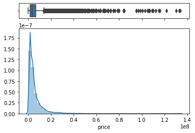

```python
# Cut the window in 2 parts
f, (ax_box, ax_hist) = plt.subplots(2, sharex=True, gridspec_kw={"height_ratios": (.15, .85)})

# Add a graph in each part
sns.boxplot(data["price"], ax=ax_box)
sns.distplot(data["price"], ax=ax_hist)

# Remove x axis name for the boxplot
ax_box.set(xlabel='')
```

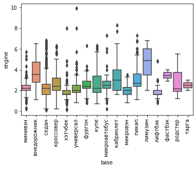

```python
#plot the box plot of salary for yes & no responses.
sns.boxplot(data.base, data.engine)
plt.xticks(rotation=90)
```

### Bivariate analysis

Let's show one bivariate analysis to get you started. `Seaborn`'s `pairplot` function will take all numeric variables and plot general correlogram. What can you say about the chart below?

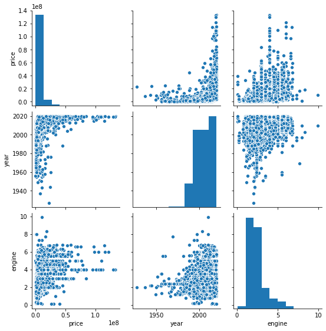

```python
# Basic correlogram
sns.pairplot(data)
#sns.plt.show()
```

## Hypothesis Testing

The null hypothesis (H0) and (two-tailed) alternative hypothesis (H1) of the one sample T test can be expressed as:

- H0: µ = x ("the sample mean is equal to the proposed population mean")
- H1: µ ≠ x ("the sample mean is not equal to the proposed population mean")

where µ is a constant proposed for the population mean and x is the sample mean.

### One sample t-test

Research Question:

- Is there a difference between `седан` engine mean in our sample and population mean?

Hypothesis:

- H0 - There is no difference
- HA - There is a difference

```python
#slice the data to select only sedans
data_sedan = data[data['base'] == " седан"]
```

Your data should include one continuous, numeric variable (represented in a column) that will be used in the analysis.

```python
#calculate mean of sedan engine sizes
data_sedan.engine.mean()
```

```
2.337185869314212
```

```python
#perform t-test, get significance level
_,p_value=stats.ttest_1samp(a=data_sedan.engine, popmean=data.engine.mean())
p_value
```

```
1.377074552602275e-122
```

```python
if p_value < 0.05:    # alpha value is 0.05 or 5%
    print("We are rejecting null hypothesis")
else:
    print("We are failing to reject null hypothesis")
```

```
We are rejecting null hypothesis
```